# Bioconductor: Quality control and normalization

Davide Risso (inspired by Åsa Björklund & Paulo Czarnewski and by Aaron Lun)

October 14, 2019

# Get data

In this tutorial, we will be using a publicly available dataset from 10X Genomics, available throught the Bioconductor `TENxPBMCData` package. The package uses `AnnotationHub` to download the required data and store them on local cache for reuse.

```r
library(TENxPBMCData)
sce1 <- TENxPBMCData(dataset = "pbmc3k")
y
sce2 <- TENxPBMCData(dataset = "pbmc4k")
rowData(sce1) <- rowData(sce1)[,c(1, 3)]
common <- intersect(rownames(sce1), rownames(sce2))
sce <- cbind(sce1[common,], sce2[common,])
sce
```

```
class: SingleCellExperiment
dim: 31232 7040
metadata(0):
assays(1): counts
rownames(31232): ENSG00000243485 ENSG00000237613 ... ENSG00000198695
  ENSG00000198727
rowData names(3): ENSEMBL_ID Symbol Symbol_TENx
colnames: NULL
colData names(11): Sample Barcode ... Individual Date_published
reducedDimNames(0):
spikeNames(0):
```

The data are stored in a [`SingleCellExperiment` object](https://osca.bioconductor.org/data-infrastructure.html#the-singlecellexperiment-class).

Note that the data are internally stored in a HDF5 file (.h5), which means that they are not loaded in memory, until it is necessary to do so. Many Bioconductor packages, including the ones that we will use in this tutorial, use block processing to ensure that we can work even with datasets larger than the available RAM.

```r
counts(sce)
```

```
<31232 x 7040> DelayedMatrix object of type "integer":
                   [,1]    [,2]    [,3]    [,4] ... [,7037] [,7038] [,7039] [,7040]
ENSG00000243485       0       0       0       0   .       0       0       0       0
ENSG00000237613       0       0       0       0   .       0       0       0       0
ENSG00000186092       0       0       0       0   .       0       0       0       0
ENSG00000238009       0       0       0       0   .       0       0       0       0
ENSG00000239945       0       0       0       0   .       0       0       0       0
            ...       .       .       .       .   .       .       .       .       .
ENSG00000212907       0       0       0       1   .       1       3       0       1
ENSG00000198886      10      33       3       3   .       9      28       7       6
ENSG00000198786       1       1       2       2   .       9      10       3       9
ENSG00000198695       0       0       0       0   .       0       1       0       0
ENSG00000198727       4       8       4       2   .       9      20       3       9
```

```r
seedApply(counts(sce), identity)
```

```
[[1]]
An object of class "HDF5ArraySeed"
Slot "filepath":
[1] "/home/rstudio/.cache/ExperimentHub/10f2a738583_1605"

Slot "name":
[1] "counts"

Slot "dim":
[1] 32738  2700

Slot "first_val":
[1] 0

Slot "chunkdim":
[1] 631  52


[[2]]
An object of class "HDF5ArraySeed"
Slot "filepath":
[1] "/home/rstudio/.cache/ExperimentHub/10f6ddb1381_1611"

Slot "name":
[1] "counts"

Slot "dim":
[1] 33694  4340

Slot "first_val":
[1] 0

Slot "chunkdim":
[1] 512  66
```

```r
object.size(sce)
```

```
9941608 bytes
```

Note that the `sce` object already includes several metadata, called “column data”, which can be accessed with the `colData` function.

```r
colData(sce)
```

```
DataFrame with 7040 rows and 11 columns
          Sample            Barcode         Sequence   Library Cell_ranger_version
     <character>        <character>      <character> <integer>         <character>
1         pbmc3k   AAACATACAACCAC-1   AAACATACAACCAC         1              v1.1.0
2         pbmc3k   AAACATTGAGCTAC-1   AAACATTGAGCTAC         1              v1.1.0
3         pbmc3k   AAACATTGATCAGC-1   AAACATTGATCAGC         1              v1.1.0
4         pbmc3k   AAACCGTGCTTCCG-1   AAACCGTGCTTCCG         1              v1.1.0
5         pbmc3k   AAACCGTGTATGCG-1   AAACCGTGTATGCG         1              v1.1.0
...          ...                ...              ...       ...                 ...
7036      pbmc4k TTTGGTTTCGCTAGCG-1 TTTGGTTTCGCTAGCG         1                v2.1
7037      pbmc4k TTTGTCACACTTAACG-1 TTTGTCACACTTAACG         1                v2.1
7038      pbmc4k TTTGTCACAGGTCCAC-1 TTTGTCACAGGTCCAC         1                v2.1
7039      pbmc4k TTTGTCAGTTAAGACA-1 TTTGTCAGTTAAGACA         1                v2.1
7040      pbmc4k TTTGTCATCCCAAGAT-1 TTTGTCATCCCAAGAT         1                v2.1
     Tissue_status Barcode_type   Chemistry Sequence_platform    Individual
```

[output cut: 25 more lines]

Similarly, the object contains information on the genes, called “row data”, which can be accessed with the `rowData` function.

```r
rowData(sce)
```

```
DataFrame with 31232 rows and 3 columns
                     ENSEMBL_ID       Symbol  Symbol_TENx
                    <character>  <character>  <character>
ENSG00000243485 ENSG00000243485           NA RP11-34P13.3
ENSG00000237613 ENSG00000237613      FAM138A      FAM138A
ENSG00000186092 ENSG00000186092        OR4F5        OR4F5
ENSG00000238009 ENSG00000238009 LOC100996442 RP11-34P13.7
ENSG00000239945 ENSG00000239945           NA RP11-34P13.8
...                         ...          ...          ...
ENSG00000212907 ENSG00000212907         ND4L      MT-ND4L
ENSG00000198886 ENSG00000198886          ND4       MT-ND4
ENSG00000198786 ENSG00000198786          ND5       MT-ND5
ENSG00000198695 ENSG00000198695          ND6       MT-ND6
ENSG00000198727 ENSG00000198727         CYTB       MT-CYB
```

With data in place, now we can start loading the libraries we will use in this tutorial.

```r
library(DropletUtils)
library(scater)
library(scran)
library(mbkmeans)

BiocParallel::register(BiocParallel::SerialParam())
```

# Identifying empty droplets

In droplet data (e.g., 10X Genomics, Dropseq) the libraries are made from the droplets, which are not guaranteed to cvontain a cell. Thus, we need to distinguish between cells and empty droplets based on the observed expression profiles. A complication is that empty droplets may contain ambient (i.e., extracellular) RNA that can be captured and sequenced, resulting in non-zero counts for libraries that do not contain any cell.

This step should be carried on starting from the “unfiltered” matrices from CellRanger (or similar pipeline), because these pipelines usually include a heuristic to filter out empty droplets. Here, we show how to use the functions on the `pbmc4k` data, for illustration purposes. We will use the default filtering employed by CellRanger for the remainder of the tutorial, hence the following chunks do not need to be run for the rest of the tutorial to work.

```r
library(BiocFileCache)
bfc <- BiocFileCache("raw_data", ask = FALSE)
raw.path <- bfcrpath(bfc, file.path("http://cf.10xgenomics.com/samples",
    "cell-exp/2.1.0/pbmc4k/pbmc4k_raw_gene_bc_matrices.tar.gz"))
untar(raw.path, exdir=file.path(tempdir(), "pbmc4k"))

fname <- file.path(tempdir(), "pbmc4k/raw_gene_bc_matrices/GRCh38")
sce.full <- read10xCounts(fname, col.names=TRUE)

bcrank <- barcodeRanks(counts(sce.full))

# Only showing unique points for plotting speed.
uniq <- !duplicated(bcrank$rank)
plot(bcrank$rank[uniq], bcrank$total[uniq], log="xy",
    xlab="Rank", ylab="Total UMI count", cex.lab=1.2)

abline(h=metadata(bcrank)$inflection, col="darkgreen", lty=2)
abline(h=metadata(bcrank)$knee, col="dodgerblue", lty=2)

legend("bottomleft", legend=c("Inflection", "Knee"),
        col=c("darkgreen", "dodgerblue"), lty=2, cex=1.2)
```

## Testing for empty droplets

```r
set.seed(124)
e.out <- emptyDrops(counts(sce.full))
table(e.out$FDR <= 0.001)
ncol(sce2)
```

`emptyDrops()` computes Monte Carlo p-values based on a Dirichlet-multinomial model of sampling molecules into droplets.

`emptyDrops()` assumes that libraries with total UMI counts below a certain threshold (`lower=100` by default) correspond to empty droplets. These are used to estimate the ambient expression profile against which the remaining libraries are tested. Under this definition, these low-count libraries cannot be cell-containing droplets and are excluded from the hypothesis testing.

To retain only the detected cells, we would subset our SingleCellExperiment object.

```r
sce.full <- sce.full[,which(e.out$FDR <= 0.001)]
sce.full
```

# Calculate QC

Having removed the empty droplets, we can start calculating some quality metrics. We can for example calculate the percentage of mitocondrial and ribossomal genes per cell and add to the metadata. This will be helpfull to visualize them across different metadata parameteres (i.e. datasetID and chemistry version). There are several ways of doing this, and here manually calculate the proportion of mitochondrial reads and add to the metadata table.

Citing from “Simple Single Cell” workflows (Lun, McCarthy & Marioni, 2017): “High proportions are indicative of poor-quality cells (Islam et al. 2014; Ilicic et al. 2016), possibly because of loss of cytoplasmic RNA from perforated cells. The reasoning is that mitochondria are larger than individual transcript molecules and less likely to escape through tears in the cell membrane.”

Analogously, we can calculate the proportion of gene expression coming from ribosomal proteins.

Given these set of genes, the `scater` package automatically calculates several per-cell QC metrics.

```r
mito_genes <- grep("^MT-",rowData(sce)$Symbol_TENx)
ribo_genes <- grep("^RP[SL]",rowData(sce)$Symbol_TENx)
head(mito_genes,10)
```

```
 [1] 31220 31221 31222 31223 31224 31225 31226 31227 31228 31229
```

```r
sce <- calculateQCMetrics(sce, feature_controls = list(Mito = mito_genes, Ribo = ribo_genes))
```

## QC-based filtering

A standard approach is to filter cells with low amount of reads as well as genes that are present in at least a certain amount of cells. While simple, using fixed thresholds requires knowledge of the experiment and of the experimental protocol.

An alternative approach is to use adaptive, data-driven thresholds to identify outlying cells, based on the set of QC metrics just calculated.

We identify cells that are outliers for the various QC metrics, based on the median absolute deviation (MAD) from the median value of each metric across all cells. Specifically, a value is considered an outlier if it is more than 3 MADs from the median in the “problematic” direction.

```r
qc.lib <- isOutlier(sce$total_counts, log=TRUE, nmads=3, type="lower")
qc.nexprs <- isOutlier(sce$total_features_by_counts, nmads=3, log=TRUE, type="lower")
qc.mito <- isOutlier(sce$pct_counts_Mito, nmads=3, type="higher")
qc.ribo <- isOutlier(sce$pct_counts_Ribo, nmads=3, type="higher")

discard <- qc.lib | qc.nexprs | qc.mito | qc.ribo
table(discard)
```

```
discard
FALSE  TRUE
 6678   362
```

```r
sce$discard <- discard
```

Additionaly, Extremely high number of detected genes could indicate doublets. However, depending on the cell type composition in your sample, you may have cells with higher number of genes (and also higher counts) from one cell type. In these datasets, there is also a clear difference between the v1 vs v2 10x chemistry with regards to gene detection, so it may not be fair to apply the same cutoffs to all of them. Hence, we do not discard cells that have a high number of detected genes and use specific tools to detect doublets later on.

A similar approach is implemented in the `metric_sample_filter` function of the `scone` Bioconductor package.

# Plot QC

Now we can plot some of the QC-features as violin plots.

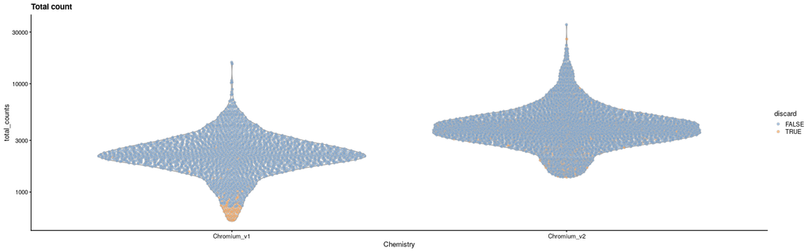

```r
plotColData(sce, x = "Chemistry", y="total_counts", colour_by = "discard") + scale_y_log10() + ggtitle("Total count")
```

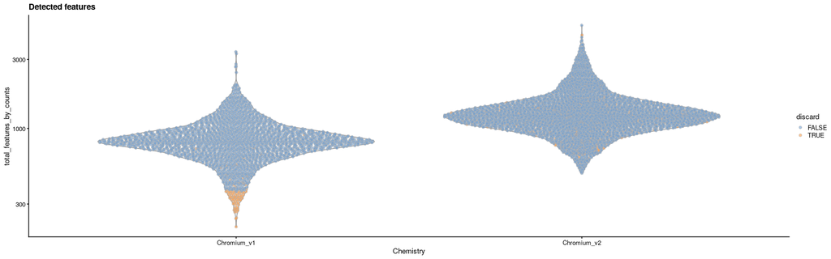

```r
plotColData(sce, x = "Chemistry", y="total_features_by_counts", colour_by = "discard") + scale_y_log10() + ggtitle("Detected features")
```

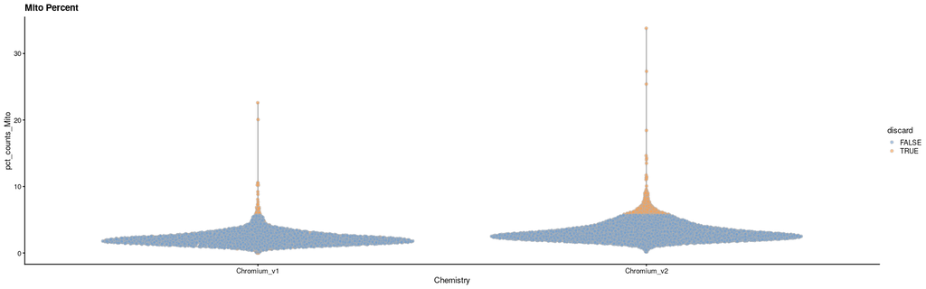

```r
plotColData(sce, x = "Chemistry", y="pct_counts_Mito", colour_by = "discard") + ggtitle("Mito Percent")
```

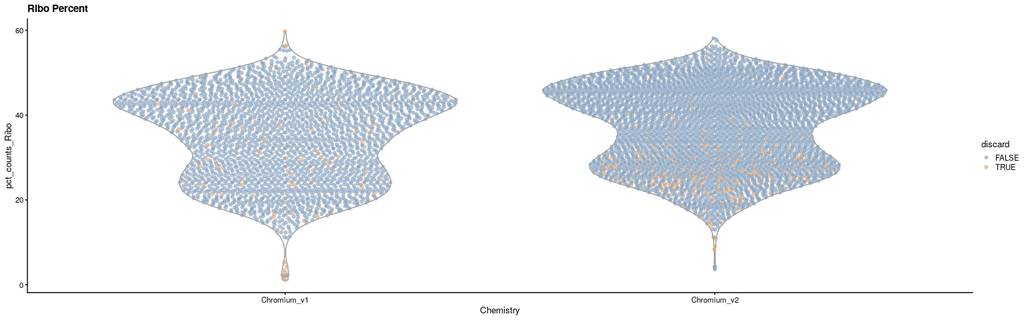

```r
plotColData(sce, x = "Chemistry", y="pct_counts_Ribo", colour_by = "discard") + ggtitle("Ribo Percent")
```

As you can see, the v2 chemistry gives higher gene detection, but similar percentage of ribosomal and mitochondrial genes. As the ribosomal proteins are highly expressed they will make up a larger proportion of the transcriptional landscape when fewer of the lowly expressed genes are detected. We can plot the different QC-measures as scatter plots.

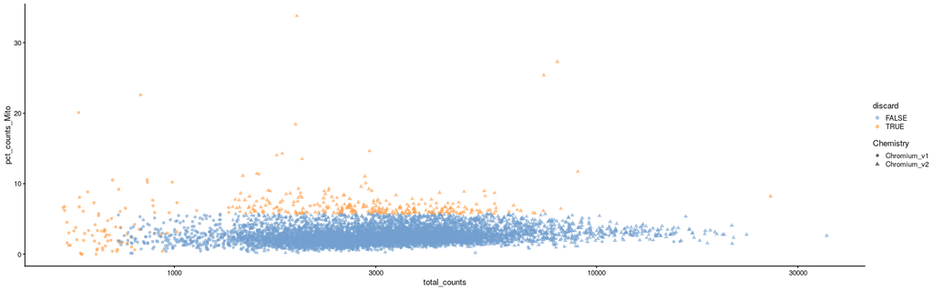

```r
plotColData(sce, x = "total_counts", y = "pct_counts_Mito", colour_by = "discard", shape_by = "Chemistry") + scale_x_log10()
```

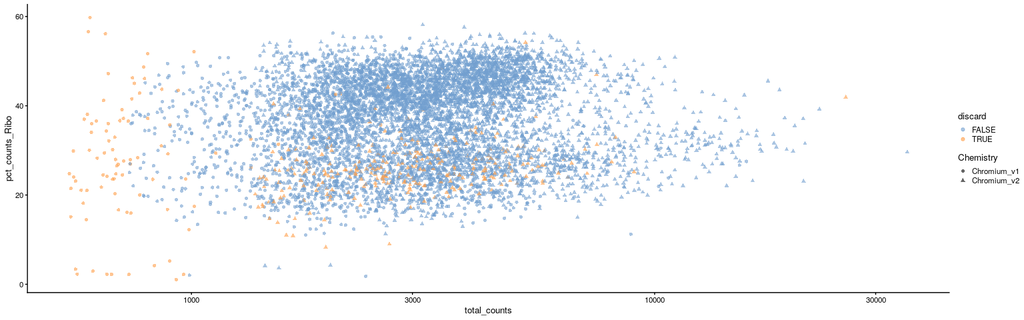

```r
plotColData(sce, x = "total_counts", y = "pct_counts_Ribo", colour_by = "discard", shape_by = "Chemistry") + scale_x_log10()
```

# Filtering

## Cell filtering

Until now we only *marked* low-quality cells. We could decide to keep all the data in the object, including the low-quality cells, and “keep an eye” on the low-quality cells at the interpretation stage.

For simplicity, it is often better to discard the low-quality cells at the QC stage. To do so it is sufficient to subset the `sce` object.

```r
sce <- sce[,!discard]
sce
```

```
class: SingleCellExperiment
dim: 31232 6678
metadata(0):
assays(1): counts
rownames(31232): ENSG00000243485 ENSG00000237613 ... ENSG00000198695 ENSG00000198727
rowData names(12): ENSEMBL_ID Symbol ... total_counts log10_total_counts
colnames: NULL
colData names(57): Sample Barcode ... pct_counts_in_top_500_features_Ribo discard
reducedDimNames(0):
spikeNames(0):
```

## Gene filtering

Naturally, we want to exclude genes that are not expressed in our system, as they do not contribute any information to our experiment.

```r
table(rowSums(counts(sce)) == 0)
```

[output not shown]

```
FALSE  TRUE
19249 11983
```

In addition, very lowly expressed genes may only contribute noise. Hence, it is often suggested to remove genes that are not expressed in at least a certain proportion of cells in the dataset. Here, we keep those genes that are expressed in at least 5% of the data.

```r
num_umis <- 1
num_cells <- 0.05*ncol(sce)
is_expressed <- rowSums(counts(sce) >= num_umis ) >= num_cells
```

[output not shown]

```r
sce <- sce[is_expressed,]
sce
```

```
class: SingleCellExperiment
dim: 5407 6678
metadata(0):
assays(1): counts
rownames(5407): ENSG00000188976 ENSG00000187608 ... ENSG00000198695 ENSG00000198727
rowData names(12): ENSEMBL_ID Symbol ... total_counts log10_total_counts
colnames: NULL
colData names(57): Sample Barcode ... pct_counts_in_top_500_features_Ribo discard
reducedDimNames(0):
spikeNames(0):
```

Note that if we expect one or more rare cell populations we might need to decrease the percentage of cells.

# Normalization

Each cell is sequenced at a different sequencing depth. This difference is a combination of different experimental factors, such as cDNA capture and PCR amplification. Normalization aims to remove these differences to ensure that the when we compare expression profiles between cells we are measuring biology and not technical biases.

Here, we focus on “scaling normalization”, which is the simplest and most common normalization strategy. As the name suggests, it simply involves scaling the number of reads by a cell-specific factor, often known as a *size factor*.

The easiest option is to divide the counts of each cell by the total number of reads. This can be done in the `scater`.

```r
lib.sf <- librarySizeFactors(sce)
summary(lib.sf)
```

```
   Min. 1st Qu.  Median    Mean 3rd Qu.    Max.
 0.1986  0.6247  0.8838  1.0000  1.2056  9.4696
```

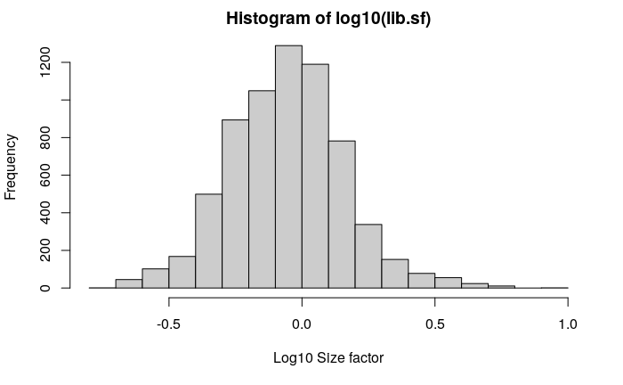

```r
hist(log10(lib.sf), xlab="Log10 Size factor", col='grey80')
```

While simple and intuitive, this strategy may be problematic when there is an imbalance in differential expression among cells, e.g., when few highly expressed genes are also those that mark each cell type. This is a well-known problem in bulk RNA-seq and many normalization methods have been shown to work better than library size normalization (e.g., TMM or DESeq normalization).

However, single-cell data can be problematic for these methods, due to the large number of zero and low counts. To overcome this, the `scran` normalization pools together similar cells to compute and then deconvolve size factors. To avoid pooling together very different cells, a quick clustering is performed prior to the pooling and only cells from the same cluster can be pooled.

The `scran` package has a `quickCluster` function, but here we use the faster mini-batch k-means algorithm for this initial step.

```r
set.seed(888)
mbkm <- mbkmeans(sce, clusters = 10, reduceMethod = NA)
table(mbkm$Clusters)
```

```
   1    2    3    4    5    6    7    8    9   10
 578  972  497   13  741 1316  855  131 1402  173
```

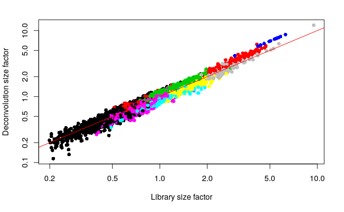

```r
sce <- computeSumFactors(sce, clusters=mbkm$Clusters)

plot(lib.sf, sizeFactors(sce), xlab="Library size factor",
    ylab="Deconvolution size factor", log='xy', pch=16,
    col=mbkm$Clusters)
abline(a=0, b=1, col="red")
```

Once we have the appropriate size factors, we can transform the data using the `scater` package.

```r
sce <- scater::normalize(sce)
sce
```

```
class: SingleCellExperiment
dim: 5407 6678
metadata(1): log.exprs.offset
assays(2): counts logcounts
rownames(5407): ENSG00000188976 ENSG00000187608 ... ENSG00000198695 ENSG00000198727
rowData names(12): ENSEMBL_ID Symbol ... total_counts log10_total_counts
colnames: NULL
colData names(57): Sample Barcode ... pct_counts_in_top_500_features_Ribo discard
reducedDimNames(0):
spikeNames(0):
```

```r
logcounts(sce)
```

```
<5407 x 6678> DelayedMatrix object of type "double":
                     [,1]      [,2]      [,3] ...   [,6677]   [,6678]
ENSG00000188976  0.000000  0.000000  0.000000   .  0.000000  0.000000
ENSG00000187608  0.000000  0.000000  1.170138   .  1.183913  0.000000
ENSG00000078808  0.000000  0.000000  1.170138   .  0.000000  0.000000
ENSG00000160087  0.000000  0.000000  0.000000   .  0.000000  0.000000
ENSG00000127054  0.000000  0.000000  0.000000   .  0.000000  0.000000
            ...         .         .         .   .         .         .
ENSG00000212907 0.0000000 0.0000000 0.0000000   . 0.0000000 0.9988313
ENSG00000198886 3.9016968 4.6010242 2.2482296   . 3.3079307 2.8053509
ENSG00000198786 1.2597905 0.7698663 1.8076282   . 2.2677643 3.3198238
ENSG00000198695 0.0000000 0.0000000 0.0000000   . 0.0000000 0.0000000
ENSG00000198727 2.7177451 2.7313775 2.5852813   . 2.2677643 3.3198238
```

This function adds a `logcounts` slot to the object with the normalized data.

# Doublet detection

Doublets are artifactual libraries generated from two cells. This happens if two cells are mistakenly captured in the same droplet. Doublets are particularly problematic for two reasons: (a) having twice as much the RNA of a single cell they appear as an extremely good quality sample; (b) they can be mistaken for intermediate populations or transitory states that do not actually exist.

We can infer doublets with computational approaches. Two approaches are implemented in the `scran` package. One needs cluster information and one does not. Here, we use the clustering results obtained earlier for simplicity, but a proper cluster analysis (seen in later lectures) would be preferable here.

## Using cluster information

The `doubletCluster()` function identifes *clusters* with expression profiles lying between two other clusters. Considering every possible triplet of clusters, the method uses the number of DE genes, the median library size, and the proporion of cells in the cluster to mark clusters as possible doublets.

```r
set.seed(333)
dbl.out <- doubletCluster(sce, mbkm$Clusters)
dbl.out
```

```
DataFrame with 10 rows and 9 columns
       source1     source2         N            best               p.value         lib.size1         lib.size2                prop
   <character> <character> <integer>     <character>             <numeric>         <numeric>         <numeric>           <numeric>
8           10           5         0 ENSG00000198763     0.786693566587063  1.14728492983527 0.452837095790116  0.0196166516921234
10           4           3         0 ENSG00000203747     0.117093138746492  1.85045734950011 0.469261859178898   0.025905959868224
5            7           6         1 ENSG00000251562  1.93519641117096e-96    1.291565615737 0.809350579358663   0.110961365678347
6            5           4        45 ENSG00000150045  2.67663777277273e-11  1.23555851506576  5.79257532878309    0.19706498951782
4           10           2        65 ENSG00000158062  1.11741567263486e-09 0.540406943326819 0.142171513967123 0.00194669062593591
9            6           1        66 ENSG00000213402 1.36914320388869e-187  1.77616794795979  1.72531046717918    0.20994309673555
7            5           4        70 ENSG00000177600  4.00497986877925e-06 0.774254120592531  3.62987690381807   0.128032345013477
3            4           1       189 ENSG00000163221  5.17291015775857e-43  3.94333635539438 0.661264732547597  0.0744234800838574
2            9           7       242 ENSG00000142541 5.05535470531125e-108 0.683646654538104   1.9377400444714     0.1455525606469
1            4           3       293 ENSG00000128383     2.03735403382e-36  5.96332476435304  1.51225364181662  0.0865528601377658
                                  all.pairs
                            <DataFrameList>
8       10:5:0:...,10:7:0:...,5:4:3:...,...
10       4:3:0:...,4:1:7:...,8:4:52:...,...
5       7:6:1:...,8:7:17:...,7:4:35:...,...
6      5:4:45:...,8:5:83:...,7:4:90:...,...
4   10:2:65:...,10:7:71:...,10:5:77:...,...
9     6:1:66:...,4:2:97:...,5:1:102:...,...
7     5:4:70:...,5:2:74:...,8:2:117:...,...
3  4:1:189:...,8:4:292:...,10:4:316:...,...
2   9:7:242:...,5:4:245:...,7:4:246:...,...
1   4:3:293:...,9:4:293:...,4:2:312:...,...
```

```r
rownames(dbl.out)[isOutlier(dbl.out$N, type="lower", nmads=3, log=TRUE)]
```

```
[1] "8"  "10"
```

These clusters are marked as possible doublet clusters, so care should be taken when interpreting their biological identity.

## Using simulations

The other approach uses simulation of in silico doublets, which are then compared to the original cells. If some cells look similar to the simulated doublets, they are likely to be doublets themselves.

The advantage of this approach is that it produces a “doublet score” for each cell, at a cost of more computational burden.

```r
dbl.dens <- doubletCells(sce)
summary(dbl.dens)
sce$DoubletScore <- log10(dbl.dens+1)
boxplot(sce$DoubletScore ~ mbkm$Clusters)
```

[output not shown]

Finally, let’s save the QC-filtered, normalized data for further analysis. Because our data are in HDF5 format, we use a specialized function.

```r
saveHDF5SummarizedExperiment(sce, dir="data/se", replace = TRUE)
```

[output not shown]